# Proyecto: Exploratory Data Analysis

Abelardo Monsalve

2025-05-06

# Análisis de Datos Sociodemográficos.

Una de las interrogantes asociadas con el análisis de los datos sociodemográficos gira en torno a los factores que influyen en el nivel de ingreso de los habitantes de una localidad.

Estos datos, en su mayoría, contienen información demográfica y socioeconómica de las personas que la componen, tales cómo:

- Ingresos
- Edad
- Nivel educativo
- Ocupación
- Tamaño del asentamiento, entre otros.

En función de estos atributos podemos orientar nuestro objetivo incial

*Objetivo:* *¿Qué factores insiden en el nivel de ingreso de los habitantes de una ciudad?*

# Cargando Librerias

```python
# ====================================
# Carga de librerías necesarias
# ====================================
import pandas as pd
import numpy as np
import matplotlib.pyplot as plt
import seaborn as sns
from scipy import stats
import statsmodels.api as sm
import statsmodels.formula.api as smf
import pingouin as pg
import warnings
warnings.filterwarnings('ignore')

## Cargando los datos

data_df = pd.read_csv("sgdata.csv")
data_df.info()
```

```
<class 'pandas.core.frame.DataFrame'>
RangeIndex: 2000 entries, 0 to 1999
Data columns (total 8 columns):
 #   Column           Non-Null Count  Dtype
---  ------           --------------  -----
 0   ID               2000 non-null   int64
 1   Sex              2000 non-null   int64
 2   Marital status   2000 non-null   object
 3   Age              2000 non-null   int64
 4   Education        2000 non-null   object
 5   Income           2000 non-null   int64
 6   Occupation       2000 non-null   object
 7   Settlement size  2000 non-null   int64
dtypes: int64(5), object(3)
memory usage: 125.1+ KB
```

# Limpieza y preparación de datos

```python
# Creamos una copia del DataFrame original para trabajar con él
df = data_df.copy()

# Verificamos si hay filas con datos faltantes en variables relevantes
if df.isnull().sum().any():
    print("Hay datos faltantes en las siguientes columnas:")
    print(df.isnull().sum()[df.isnull().sum() > 0])
else:
    print("No hay datos faltantes en las columnas.")
```

```
No hay datos faltantes en las columnas.
```

# Renombrando y recodificando variables.

```python
df.rename(columns={'Marital status': 'estado_civil', 'Age': 'edad', 'Education': 'educacion', 'Occupation': 'ocupacion', 'Income': 'ingresos','Settlement size': 'tamano_asentamiento'}, inplace=True)

# Recodificamos los valores de la variable 'Sexo'
df['sexo'] = df['Sex'].map({1: 'hombre', 0 : 'mujer'})
```

# Mostrando algunas variables

```python
from tabulate import tabulate

df_grouped = df['ingresos'].groupby(df['educacion']).agg(['mean', 'std', 'count']).reset_index()
df_grouped.columns = ['educacion', 'Media de ingresos', 'Dev_Std ingresos', 'Cantidad']
print(tabulate(df_grouped, headers='keys', tablefmt='fancy_grid'))
```

```
╒════╤═══════════════╤═════════════════════╤════════════════════╤════════════╕
│    │ educacion     │   Media de ingresos │   Dev_Std ingresos │   Cantidad │
╞════╪═══════════════╪═════════════════════╪════════════════════╪════════════╡
│  0 │ Postgrado     │              146818 │            37635.7 │         36 │
├────┼───────────────┼─────────────────────┼────────────────────┼────────────┤
│  1 │ Secundaria    │              116368 │            32636.6 │       1386 │
├────┼───────────────┼─────────────────────┼────────────────────┼────────────┤
│  2 │ otro          │              115068 │            40058.8 │        287 │
├────┼───────────────┼─────────────────────┼────────────────────┼────────────┤
│  3 │ universitario │              145406 │            48501.6 │        291 │
╘════╧═══════════════╧═════════════════════╧════════════════════╧════════════╛
```

# Gráficos de distribución de la Variable Ingresos

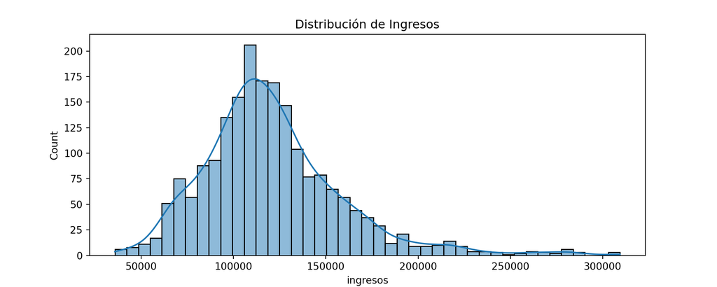

```python
# Histograma y Densidad de la variable ingresos
plt.figure(figsize=(10,4))
sns.histplot(df['ingresos'], kde=True)
plt.title('Distribución de Ingresos')
plt.show()
```